# Logistic Regression

For DATA50XX by ctong

### Learning Outcomes

- Understand the purpose of logistic regression
- Build binary and multinomial logistic regression models in R
- Interpret the model outputs in plain language
- Assess model performance using accuracy, ROC, and AUC

## Overview

Logistic regression is a technique use to predict **categorical variables** instead of scale variables.

- **Binary logistic regression** predicts a categorical variable with two outcomes (e.g., Yes/No)
- **Multinomial logistic regression** predicts a categorical variable with more than two outcomes (e.g., Buy, Sell, Hold)

Examples:

- Predicting whether a customer will buy a product (Yes/No)
- Predicting an investor’s action for a stock: Buy, Sell, Hold

## Binomial Logistic Regression

Binary logistic regression estimates the **probability** that something belongs to one category versus the other.

- A probability > 0.5 is typically interpreted as a “yes.”
- R uses the `glm()` function with `family = binomial`.

#### Demo with `titanic`

The `titanic` dataset contains information about passengers aboard the Titanic and whether they survived the shipwreck.

| Variable | Description |
| --- | --- |
| `PassengerId` | Unique ID for each passenger |
| `Survived` | **Target variable**: 0 = No, 1 = Yes |
| `Pclass` | Ticket class: 1 = 1st, 2 = 2nd, 3 = 3rd |
| `Name` | Passenger’s name |
| `Sex` | Gender |
| `Age` | Age in years (may have missing values) |
| `SibSp` | Number of siblings or spouses aboard |
| `Parch` | Number of parents or children aboard |
| `Ticket` | Ticket number |
| `Fare` | Passenger fare (in pounds) |
| `Cabin` | Cabin number (many missing values) |
| `Embarked` | Port of embarkation: C=Cherbourg, Q=Queenstown, S=Southampton |

```r
df=na.omit(titanic_train) # remove observations with missing data
df$Survived <- factor(df$Survived, labels = c("No", "Yes"))

model_binary <- glm(Survived ~ Pclass+Sex+Age+Fare, data = df, family = binomial)
summary(model_binary)
```

```
##
## Call:
## glm(formula = Survived ~ Pclass + Sex + Age + Fare, family = binomial,
##     data = df)
##
## Coefficients:
##               Estimate Std. Error z value Pr(>|z|)
## (Intercept)  4.9880403  0.5721894   8.717  < 2e-16 ***
## Pclass      -1.2697410  0.1586252  -8.005 1.20e-15 ***
## Sexmale     -2.5181969  0.2078562 -12.115  < 2e-16 ***
## Age         -0.0367073  0.0076795  -4.780 1.75e-06 ***
## Fare         0.0005373  0.0021821   0.246    0.805
## ---
## Signif. codes:  0 '***' 0.001 '**' 0.01 '*' 0.05 '.' 0.1 ' ' 1
##
## (Dispersion parameter for binomial family taken to be 1)
##
##     Null deviance: 964.52  on 713  degrees of freedom
## Residual deviance: 647.23  on 709  degrees of freedom
## AIC: 657.23
##
## Number of Fisher Scoring iterations: 5
```

```r
# Predict probability of survival
prob <- predict(model_binary, type = "response")

# Class prediction (threshold = 0.5)
predicted_class <- ifelse(prob > 0.5, "Yes", "No")
```

#### Model Fit

```r
# Confusion matrix
table(Predicted = predicted_class, Actual = df$Survived)
```

```
##          Actual
## Predicted  No Yes
##       No  357  81
##       Yes  67 209
```

```r
# Accuracy rate = Proportion of correct predictions across all observations
mean(predicted_class==df$Survived)
```

```
## [1] 0.7927171
```

Using prediction accuracy rate alone to evaluate a binary classification model can be problematic if there is a class imbalance, i.e., a much higher proportion of one outcome than the other. Can you think of why this would be problematic? *Hint: Consider a hypothetical shipwreck where 90% of the passengers survived.*

## ROC and AUC

### What is an ROC Curve?

The ROC (Receiver Operating Characteristic) curve shows how well your model distinguishes between survivors and non-survivors by plotting **True Positive Rate (Sensitivity)** against **False Positive Rate (1-Specificity)** at different thresholds (from 1 down to 0) for class prediction.

Let us revisit the confusion matrix for predicting survivors in the Titanic data.

```r
# Confusion matrix
table(Predicted = predicted_class, Actual = df$Survived)
```

```
##          Actual
## Predicted  No Yes
##       No  357  81
##       Yes  67 209
```

- True Positive (TP) = 209
- False Positive (FP) = 67
- True Negative (TN) = 357
- False Negative (FN) = 81

### True Positive Rate (TPR) = Sensitivity

- Proportion of actual survivors predicted correctly
- TP / (TP + FN)

### False Positive Rate (FPR) = 1 - Specificity

- Proportion of actual non-survivors predicted incorrectly
- FP / (FP + TN)

### Plotting a ROC Curve manually

| Threshold | TP | FP | TN | FN | TPR (Sensitivity) | FPR (1-Specificity) |
| --- | --- | --- | --- | --- | --- | --- |
| 0.9 | 67 | 2 | 422 | 223 | 67 / (67+223) ≈ 0.231 | 2 / (2+422) ≈ 0.005 |
| 0.7 | 156 | 18 | 406 | 134 | 0.538 | 0.042 |
| 0.5 | 209 | 67 | 357 | 81 | 0.721 | 0.158 |
| 0.3 | 244 | 123 | 301 | 46 | 0.841 | 0.290 |
| 0.1 | 268 | 295 | 129 | 22 | 0.924 | 0.696 |

### Plotting ROC in R

```r
actual <- df$Survived
roc_obj <- roc(actual, prob)
```

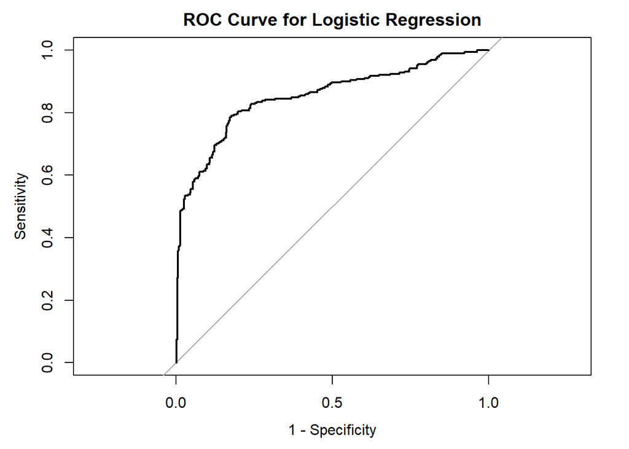

```r
plot(roc_obj, legacy.axes=TRUE, main = "ROC Curve for Logistic Regression")
```

```r
auc(roc_obj)
```

```
## Area under the curve: 0.8521
```

### What to look for in the ROC

- A diagonal line means the model is no better than guessing.
- A curve that hugs the top-left corner of the plot is ideal.
- The more the curve bows away from the diagonal, the better your model.
- AUC (Area Under the Curve) measures overall performance:
  - 0.5 = guessing
  - Above 0.7 = decent
  - Above 0.9 = excellent

### Cross-validation with Caret

```r
# Cross-validation
control <- trainControl(method = "cv", number = 5, classProbs = TRUE, summaryFunction = twoClassSummary, verboseIter = FALSE, savePredictions=TRUE)
set.seed(123)
model_cv_bin <- train(Survived ~ Pclass+Sex+Age+Fare,
                      data = df,
                      method = "glm",
                      family = "binomial",
                      trControl = control,
                      metric = "ROC")
print(model_cv_bin)
```

```
## Generalized Linear Model
##
## 714 samples
##   4 predictor
##   2 classes: 'No', 'Yes'
##
## No pre-processing
## Resampling: Cross-Validated (5 fold)
## Summary of sample sizes: 571, 571, 571, 572, 571
## Resampling results:
##
##   ROC        Sens       Spec
##   0.8480706  0.8443697  0.7172414
```

### Final model with optimal threshold

```r
library(pROC)

# Get out-of-fold predicted probabilities and true classes
preds <- model_cv_bin$pred
roc_obj <- roc(preds$obs, preds$Yes)  # assuming "yes" is the positive class
# Find best threshold with highest Youden's J statistic, which is sens + spec - 1
best_thresh <- coords(roc_obj, "best", best.method = "youden", transpose = FALSE)$threshold
print(best_thresh)
```

```
## [1] 0.4249877
```

```r
final_predicted_class <- ifelse(prob > best_thresh, "Yes", "No")

# Confusion matrix
table(Predicted = final_predicted_class, Actual = df$Survived)
```

```
##          Actual
## Predicted  No Yes
##       No  343  60
##       Yes  81 230
```

```r
# Accuracy rate = Proportion of correct predictions across all observations
mean(final_predicted_class==df$Survived)
```

```
## [1] 0.802521
```

## Multinomial Logistic Regression

Multinomial logistic regression is used to predict a categorical variable with more than 2 categories (e.g., apple, banana, orange). It estimates the probability for an observation to fall into each of the categories, with the probabilities summing up to 1. The category with the highest probability is the predicted outcome.

### Demo: iris Dataset

The dataset contains 150 observations (rows), each representing a single iris flower, with 5 variables:

| Variable | Type | Description |
| --- | --- | --- |
| `Sepal.Length` | Numeric | Length of the sepal in centimeters |
| `Sepal.Width` | Numeric | Width of the sepal in centimeters |
| `Petal.Length` | Numeric | Length of the petal in centimeters |
| `Petal.Width` | Numeric | Width of the petal in centimeters |
| `Species` | Factor | Species of iris: `setosa`, `versicolor`, `virginica` |

### Predict Species of iris from Sepal Length and Width

```r
library(nnet)
data(iris)

model_multi <- multinom(Species ~ Sepal.Length + Sepal.Width, data = iris)
summary(model_multi)
```

```
## Call:
## multinom(formula = Species ~ Sepal.Length + Sepal.Width, data = iris)
##
## Coefficients:
##            (Intercept) Sepal.Length Sepal.Width
## versicolor   -92.09924     40.40326   -40.58755
## virginica   -105.10096     42.30094   -40.18799
##
## Std. Errors:
##            (Intercept) Sepal.Length Sepal.Width
## versicolor    26.27831     9.142717    27.77772
## virginica     26.37025     9.131119    27.78875
##
## Residual Deviance: 110.425
## AIC: 122.425
```

```r
predicted <- predict(model_multi)
table(Predicted = predicted, Actual = iris$Species)
```

```
##             Actual
## Predicted    setosa versicolor virginica
##   setosa         50          0         0
##   versicolor      0         38        13
##   virginica       0         12        37
```

### Cross-Validation for Multinomial Logistic Regression

```r
library(nnet)
data(iris)
control <- trainControl(method = "cv", number = 5, verboseIter = FALSE)
set.seed(123)
model_cv_multi <- train(Species ~ Sepal.Length + Sepal.Width,
                        data = iris,
                        method = "multinom",
                        trace=FALSE,
                        trControl = control)
print(model_cv_multi)
```

```
## Penalized Multinomial Regression
##
## 150 samples
##   2 predictor
##   3 classes: 'setosa', 'versicolor', 'virginica'
##
## No pre-processing
## Resampling: Cross-Validated (5 fold)
## Summary of sample sizes: 120, 120, 120, 120, 120
## Resampling results across tuning parameters:
##
##   decay  Accuracy   Kappa
##   0e+00  0.8200000  0.73
##   1e-04  0.8200000  0.73
##   1e-01  0.8133333  0.72
##
## Accuracy was used to select the optimal model using the largest value.
## The final value used for the model was decay = 1e-04.
```

```r
best_decay<-model_cv_multi$bestTune$decay
```

- **Decay** refers to **weight decay**, which is the strength of L2 regularization. High decay results in a simpler model that is less likely to overfit. Low decay produces a more flexible model, but with a higher risk of overfitting.
- **Accuracy** refers to proportion of total correct predictions. Can be misleading if there is a class imbalance.
- **Kappa** measures the **chance-adjusted** agreement between predicted and actual classes. 0 = predictions are no better than random chance; 1 = perfect agreement.
  - Above 0.8: Excellent
  - 0.6 to 0.8: Good
  - 0.4 to 0.6: Moderate
  - Below 0.4: Poor

### Final model with optimal decay value

```r
final_model_multi=multinom(Species ~ Sepal.Length + Sepal.Width, data = iris, decay=best_decay, trace=FALSE)

summary(final_model_multi)
```

```
## Call:
## multinom(formula = Species ~ Sepal.Length + Sepal.Width, data = iris,
##     decay = best_decay, trace = FALSE)
##
## Coefficients:
##            (Intercept) Sepal.Length Sepal.Width
## versicolor   -42.49458     18.26385   -17.92327
## virginica    -55.42867     20.15164   -17.52557
##
## Std. Errors:
##            (Intercept) Sepal.Length Sepal.Width
## versicolor    27.86347     10.27397    10.43367
## virginica     28.04703     10.28659    10.45352
##
## Residual Deviance: 112.4996
## AIC: 124.4996
```

## Lab

### Exercise 1: `PimaIndiansDiabetes2` dataset

The Pima, also known as Akimel O’odham, are an Indigenous people of the Americas with a high prevalence of type 2 diabetes.

Use the following code to load the `PimaIndiansDiabetes2` dataset and remove observations with missing data.

```r
install.packages("mlbench")
library(mlbench)
data(PimaIndiansDiabetes2)
df<-na.omit(PimaIndiansDiabetes2)
```

1. Explore the data set.
2. Build a model to predict `diabetes` from `mass`, `age` and `pedigree`.
3. Create a confusion matrix and compute accuracy. Is accuracy a good measure of fit for this model?
4. Perform a 5-fold cross-validation and evaluate model fit.

### Exercise 2: `iris` dataset

1. Use `Petal.Length` and `Petal.Width` to predict species in `iris` dataset.
2. Create a confusion matrix.
3. Which species is hardest to classify?